# Invisible Crisis: Healthcare Waste Management Around the World

A UNICEF Data Analysis Report

Author

Satvik Rajput

Published

April 13, 2026

## Introduction

Every year, healthcare facilities worldwide generate millions of tonnes of medical waste — used needles, contaminated dressings, expired medicines, and biological material. When this waste is **not properly managed**, it becomes a silent public health emergency: spreading disease, contaminating water, and endangering the workers and communities closest to it.

This report examines a critical UNICEF indicator: the **proportion of healthcare facilities with basic health care waste management services**. The data, spanning from 2000 to 2023, reveals stark global inequalities — and a troubling truth: in the countries that need health infrastructure the most, the systems to safely manage its byproducts are often weakest.

> *“A healthcare system is only as strong as its ability to safely manage the risks it generates.”*

### Key Questions We Explore

- Which countries and regions are leading — and lagging — in healthcare waste management?
- Has the situation improved over time?
- Is there a link between a country’s wealth and its waste management capacity?
- Which regions carry the greatest burden of inadequate waste management?

## Data & Methodology

```python
import polars as pl
import pandas as pd
import numpy as np
import geopandas as gpd
from plotnine import *
import warnings
warnings.filterwarnings("ignore")

# --- Load data ---
ind = pl.read_csv("unicef_indicator_2.csv")
meta = pl.read_csv("unicef_metadata.csv")

# --- Basic EDA ---
print("Indicator dataset shape:", ind.shape)
print("Metadata dataset shape:", meta.shape)
print("\nIndicator columns:", ind.columns)
print("\nYears covered:", sorted(ind["time_period"].unique().to_list()))
print("\nNumber of countries:", ind["country"].n_unique())
print("\nObs value stats:")
print(ind["obs_value"].describe())
```

```
Indicator dataset shape: (1311, 14)
Metadata dataset shape: (13715, 15)

Indicator columns: ['country', 'alpha_2_code', 'alpha_3_code', 'numeric_code', 'indicator', 'time_period', 'obs_value', 'sex', 'unit_multiplier', 'unit_of_measure', 'observation_status', 'observation_confidentaility', 'time_period_activity_related_to_when_the_data_are_collected', 'current_age']

Years covered: [2000, 2001, 2002, 2003, 2004, 2005, 2006, 2007, 2008, 2009, 2010, 2011, 2012, 2013, 2014, 2015, 2016, 2017, 2018, 2019, 2020, 2021, 2022, 2023]

Number of countries: 99

Obs value stats:
shape: (9, 2)
┌────────────┬───────────┐
│ statistic  ┆ value     │
│ ---        ┆ ---       │
│ str        ┆ f64       │
╞════════════╪═══════════╡
│ count      ┆ 1311.0    │
│ null_count ┆ 0.0       │
│ mean       ┆ 52.144726 │
│ std        ┆ 33.084375 │
│ min        ┆ 0.0       │
│ 25%        ┆ 23.938643 │
│ 50%        ┆ 44.601286 │
│ 75%        ┆ 84.7      │
│ max        ┆ 100.0     │
└────────────┴───────────┘
```

```python
# --- Merge indicator with metadata on country + year ---
merged = ind.join(
    meta,
    left_on=["country", "time_period"],
    right_on=["country", "year"],
    how="left"
)

# --- Filter to Total sex only (no disaggregation needed) ---
df = merged.filter(pl.col("sex") == "Total")

# --- Drop rows where obs_value is null ---
df = df.filter(pl.col("obs_value").is_not_null())

# --- Latest available year per country (for snapshot maps/bar charts) ---
latest_per_country = (
    df.group_by("country")
    .agg([
        pl.col("obs_value").last().alias("latest_value"),
        pl.col("time_period").last().alias("latest_year"),
        pl.col("alpha_3_code").last(),
        pl.col("GDP per capita (constant 2015 US$)").mean().alias("gdp_per_capita"),
        pl.col("Life expectancy at birth, total (years)").mean().alias("life_expectancy"),
        pl.col("Population, total").last().alias("population"),
    ])
    .sort("country")
)

# --- Regional grouping using alpha_2_code first letter heuristic ---
# We'll use a manual region mapping based on alpha_3_code for a cleaner approach
# For simplicity, we compute a continent approximation via geopandas world dataset
world = gpd.read_file(
    "https://naciscdn.org/naturalearth/110m/cultural/ne_110m_admin_0_countries.zip"
)
world = world.rename(columns={"NAME": "name", "CONTINENT": "continent", "ISO_A3": "iso_a3"})
country_region = world[["name", "continent", "iso_a3"]].rename(
    columns={"iso_a3": "alpha_3_code", "continent": "region"}
)

# Convert to polars using a simple dict-based constructor
region_pl = pl.DataFrame(
    {
        "alpha_3_code": country_region["alpha_3_code"].astype(str).to_list(),
        "region": country_region["region"].astype(str).to_list(),
    }
)

latest_with_region = latest_per_country.join(
    region_pl.select(["alpha_3_code", "region"]),
    on="alpha_3_code",
    how="left"
)

print("Countries with data:", latest_with_region.shape[0])
print("\nLatest values sample:")
print(latest_with_region.select(["country", "latest_value", "latest_year", "region"]).head(10))
```

```
Countries with data: 99

Latest values sample:
shape: (10, 4)
┌──────────────┬──────────────┬─────────────┬────────┐
│ country      ┆ latest_value ┆ latest_year ┆ region │
│ ---          ┆ ---          ┆ ---         ┆ ---    │
│ str          ┆ f64          ┆ i64         ┆ str    │
╞══════════════╪══════════════╪═════════════╪════════╡
│ Afghanistan  ┆ 82.0         ┆ 2023        ┆ Asia   │
│ Andorra      ┆ 100.0        ┆ 2023        ┆ null   │
│ Armenia      ┆ 97.0         ┆ 2022        ┆ Asia   │
│ Bahrain      ┆ 90.288922    ┆ 2023        ┆ null   │
│ Bangladesh   ┆ 33.726383    ┆ 2023        ┆ Asia   │
│ Benin        ┆ 63.66955     ┆ 2020        ┆ Africa │
│ Bhutan       ┆ 35.9         ┆ 2023        ┆ Asia   │
│ Burkina Faso ┆ 15.224465    ┆ 2023        ┆ Africa │
│ Burundi      ┆ 76.501572    ┆ 2023        ┆ Africa │
│ Cambodia     ┆ 52.9801      ┆ 2023        ┆ Asia   │
└──────────────┴──────────────┴─────────────┴────────┘
```

## The Global Picture: A World Map

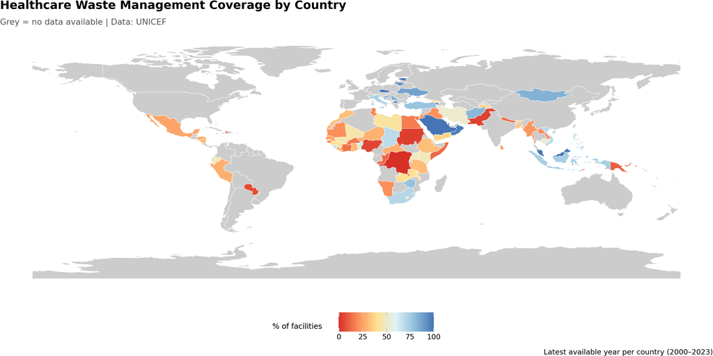

Figure 1: Proportion of healthcare facilities with basic waste management services — latest available data per country

```python
# Merge geopandas world with our indicator data
world_plot = world.merge(
    latest_per_country.to_pandas(),
    left_on="iso_a3",
    right_on="alpha_3_code",
    how="left"
)

# Convert to pandas for plotnine
map_df = world_plot[["name", "geometry", "latest_value"]].copy()
map_df = map_df.dissolve(by="name", as_index=False)

# Get centroids for plotting — convert to long/lat format
map_df_plot = map_df.copy()
map_df_plot["lon"] = map_df_plot.geometry.centroid.x
map_df_plot["lat"] = map_df_plot.geometry.centroid.y

# Use pandas for the plotnine world map
world_pd = world_plot[["name", "geometry", "latest_value"]].copy()

# plotnine world map using geom_map
p_map = (
    ggplot(world_pd)
    + geom_map(aes(fill="latest_value"), color="white", size=0.2)
    + scale_fill_gradientn(
        colors=["#d73027", "#fc8d59", "#fee090", "#e0f3f8", "#91bfdb", "#4575b4"],
        name="% of facilities",
        na_value="#cccccc",
        limits=[0, 100]
    )
    + labs(
        title="Healthcare Waste Management Coverage by Country",
        subtitle="Grey = no data available | Data: UNICEF",
        caption="Latest available year per country (2000–2023)"
    )
    + theme_void()
    + theme(
        plot_title=element_text(size=14, weight="bold"),
        plot_subtitle=element_text(size=10, color="#555555"),
        legend_position="bottom",
        legend_title=element_text(size=9),
        figure_size=(12, 6)
    )
)

p_map
```

## Regional Breakdown: Who Is Falling Behind?

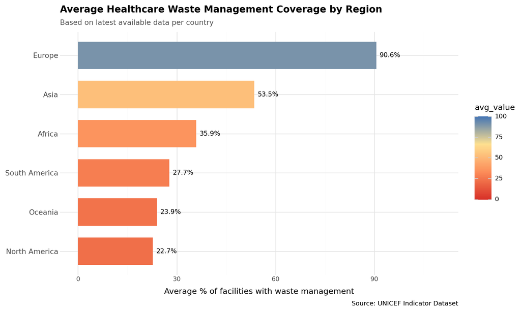

Figure 2: Average healthcare waste management coverage by world region

```python
# Group by region
region_avg = (
    latest_with_region.filter(pl.col("region").is_not_null())
    .group_by("region")
    .agg([
        pl.col("latest_value").mean().alias("avg_value"),
        pl.col("latest_value").count().alias("n_countries")
    ])
    .sort("avg_value")
)

region_pd = region_avg.to_pandas()

p_bar = (
    ggplot(region_pd, aes(x="reorder(region, avg_value)", y="avg_value", fill="avg_value"))
    + geom_col(width=0.7)
    + geom_text(
        aes(label="avg_value.round(1).astype(str) + '%'"),
        ha="left",
        nudge_y=1,
        size=9
    )
    + scale_fill_gradientn(
        colors=["#d73027", "#fc8d59", "#fee090", "#4575b4"],
        limits=[0, 100]
    )
    + coord_flip()
    + scale_y_continuous(limits=[0, 110])
    + labs(
        title="Average Healthcare Waste Management Coverage by Region",
        subtitle="Based on latest available data per country",
        x="",
        y="Average % of facilities with waste management",
        caption="Source: UNICEF Indicator Dataset"
    )
    + theme_minimal()
    + theme(
        plot_title=element_text(size=13, weight="bold"),
        plot_subtitle=element_text(size=10, color="#555555"),
        axis_text_y=element_text(size=10),
        figure_size=(10, 6)
    )
)

p_bar
```

## Does Wealth Explain It? A Scatterplot

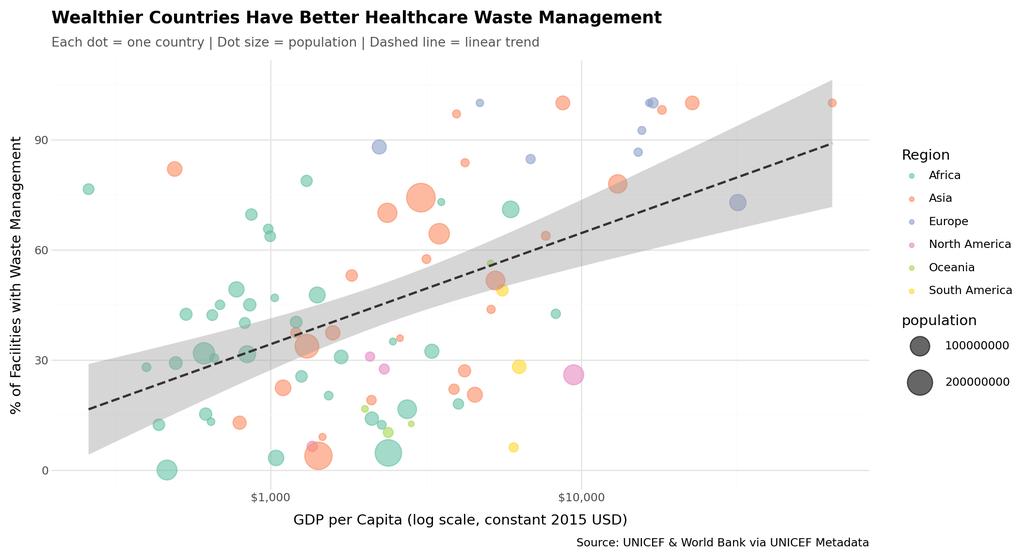

Figure 3: Relationship between GDP per capita and healthcare waste management coverage

```python
scatter_df = (
    latest_with_region
    .filter(
        pl.col("gdp_per_capita").is_not_null()
        & pl.col("latest_value").is_not_null()
        & pl.col("region").is_not_null()
    )
    .to_pandas()
)

# Log-transform GDP for better spread
scatter_df["log_gdp"] = np.log10(scatter_df["gdp_per_capita"])

p_scatter = (
    ggplot(scatter_df, aes(x="log_gdp", y="latest_value", color="region"))
    + geom_point(aes(size="population"), alpha=0.6)
    + geom_smooth(method="lm", color="#333333", se=True, linetype="dashed")
    + scale_color_brewer(type="qual", palette="Set2", name="Region")
    + scale_size_continuous(range=(2, 12))
    + scale_x_continuous(
        breaks=[2, 3, 4, 5],
        labels=["$100", "$1,000", "$10,000", "$100,000"]
    )
    + labs(
        title="Wealthier Countries Have Better Healthcare Waste Management",
        subtitle="Each dot = one country | Dot size = population | Dashed line = linear trend",
        x="GDP per Capita (log scale, constant 2015 USD)",
        y="% of Facilities with Waste Management",
        caption="Source: UNICEF & World Bank via UNICEF Metadata"
    )
    + theme_minimal()
    + theme(
        plot_title=element_text(size=13, weight="bold"),
        plot_subtitle=element_text(size=10, color="#555555"),
        legend_position="right",
        figure_size=(11, 6)
    )
)

p_scatter
```

The scatterplot reveals a **clear positive relationship** between a country’s GDP per capita and its healthcare waste management coverage. The linear regression line (dashed) confirms this trend: as national income rises, so does the proportion of facilities with waste management services. Notably, **African nations cluster in the bottom-left** — low income, low coverage — while **European countries cluster in the top-right**. However, there is meaningful variance: some middle-income countries punch above their weight, suggesting that **policy choices and political will** — not just wealth — matter.